# Обобщенные линейные модели с нормальным распределением остатков

Линейные модели…

Вадим Хайтов, Валентина Домашкина, Анастасия Лянгузова, Наталья Арбузова, Юта Тамберг, Марина Варфоломеева

Кафедра Зоологии беспозвоночных, СПбГУ

## Общая линейная модель — удобный инструмент описания связей

$y_i = \beta_0 + \beta_1 x_{1i} + ... + \beta_{p-1}x_{p-1\,i} + \varepsilon_i$,

где $\varepsilon_i \sim N(0, \sigma)$.

Предикторы в такой модели могут быть дискретными и непрерывными.

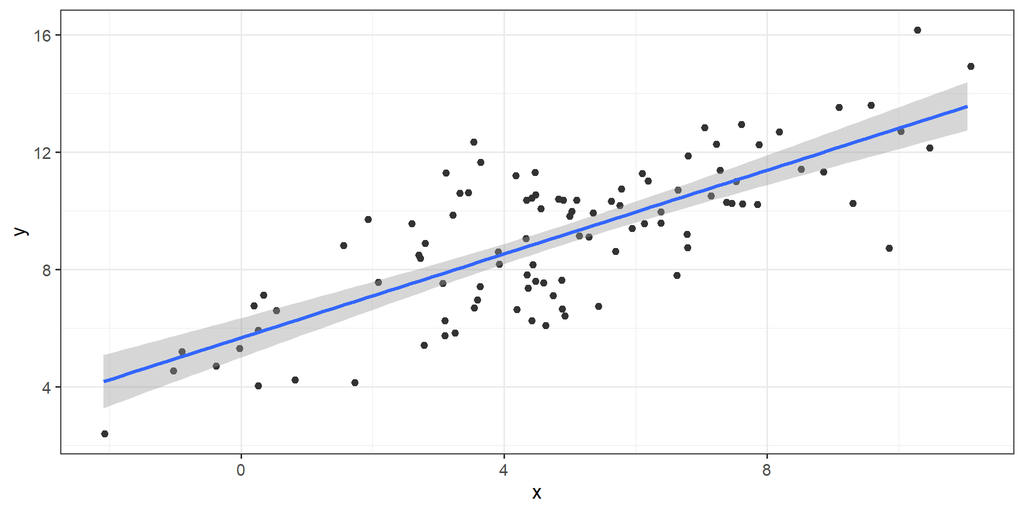

## Применимость общих линейных моделей ограничена

$y_i = \beta_0 + \beta_1 x_{1i} + ... + \beta_{p-1}x_{p-1\,i} + \varepsilon_i$,

где $\varepsilon_i \sim N(0, \sigma)$.

Т.е. на самом деле мы имеем ввиду, что переменная-отклик подчиняется нормальному распределению:

$y_i \sim N(\mu_i, \sigma)$

$E(y_i) = \mu_i = \beta_0 + \beta_1 x_{1i} + ... + \beta_{p-1}x_{p-1\,i}$

Но если отклик подчиняется другому распределению, такие модели не годятся.

Далее мы будем использовать именно этот способ записи модели (распределение отклика и линейный предиктор) мы будем использовать дальше.

## Обобщенные линейные модели

Обобщенные линейные модели (Generalized Linear Models, GLM, GLZ, GLIM) позволяют моделировать зависимости не только для нормально-распределенных величин, но и для других распределений.

Не путайте обобщенные линейные модели с общими (General Linear Models, тоже сокращаются как GLM).

# Зоопарк статистических распределений

## Важнейшие распределения из семейства экспоненциальных

Для непрерывных величин

- Нормальное распределение
- Гамма распределение
- Бета распределение (не будем рассматривать)

Для дискретных величин

- Биномиальное распределение
- Распределение Пуассона
- Отрицательное биномиальное распределение

## Нормальное распределение

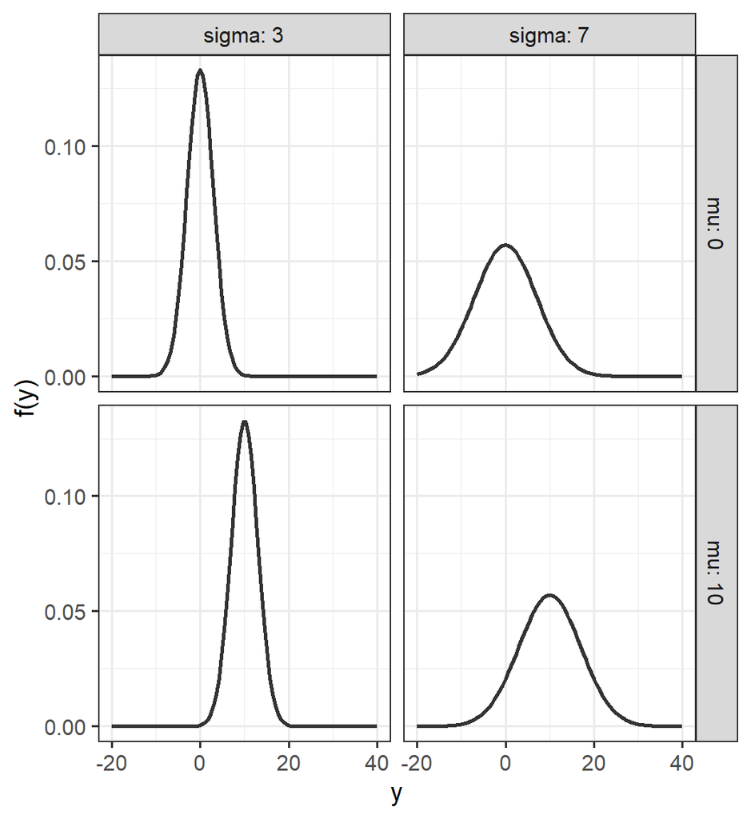

$$f(y)= \frac {1}{\sqrt{2 \pi \sigma^2}} \cdot e^{-\frac{1}{2 \sigma^2} (y - \mu)^2}$$
Параметры:

- $\mu$ – среднее;
- $\sigma$ – стандартное отклонение.

Свойства:

- $E(y) = \mu$ – мат. ожидание;
- $var(y) = \sigma^2$ – дисперсия;
- $-\infty \le y \le +\infty$, $y \in \mathbb R$ – значения.

## Гамма-распределение

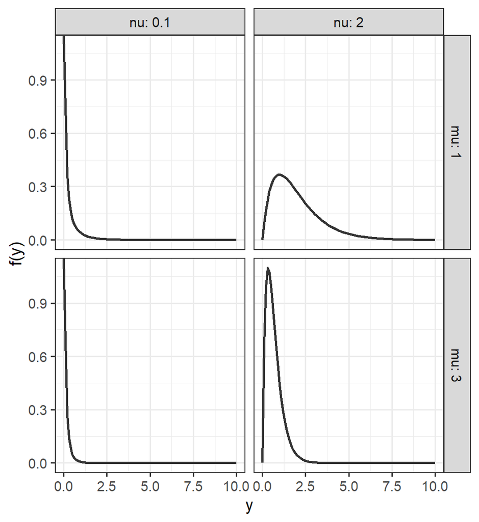

$f(y) = \frac{1}{\Gamma(\nu)}\cdot (\frac{\nu}{\mu})^{\nu} \cdot y^{\nu-1} \cdot e^{\cfrac{y \cdot \nu}{\mu}}$

Параметры:

- $\mu$ – среднее;
- $\nu$ – определяет степень избыточности дисперсии.

Свойства:

- $E(y) = \mu$ – мат. ожидание;
- $var(y) = \frac {\mu^2}{\nu}$ – дисперсия;
- $0 < y \le +\infty$, $y \in \mathbb R$ – значения.

## Биномиальное распределение

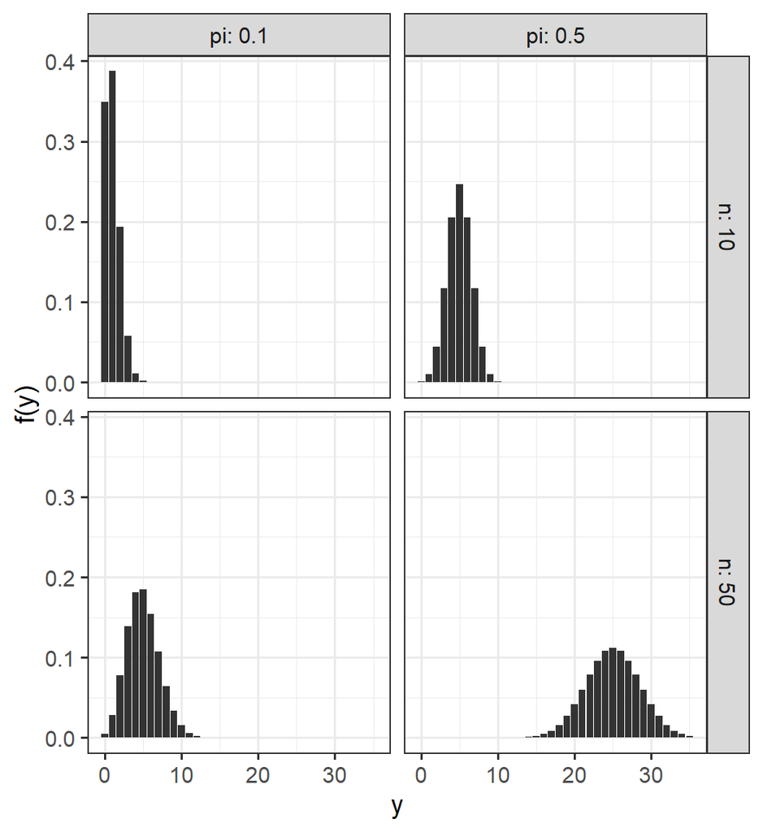

$$f(y) = \frac{n!}{y! \cdot (n-y)!} \cdot \pi^y \cdot (1 - \pi)^{n-y}$$

Параметры:

- $n$ – число объектов в испытании;
- $\pi$ – вероятность успеха в одном испытании.

Свойства:

- $E(y) = n \cdot \pi$ – мат. ожидание;
- $var(y) = n \cdot \pi \cdot (1-\pi)$ – дисперсия;
- $0 \le y \le +\infty$, $y \in \mathbb{N}$ – значения.

## Распределение Пуассона

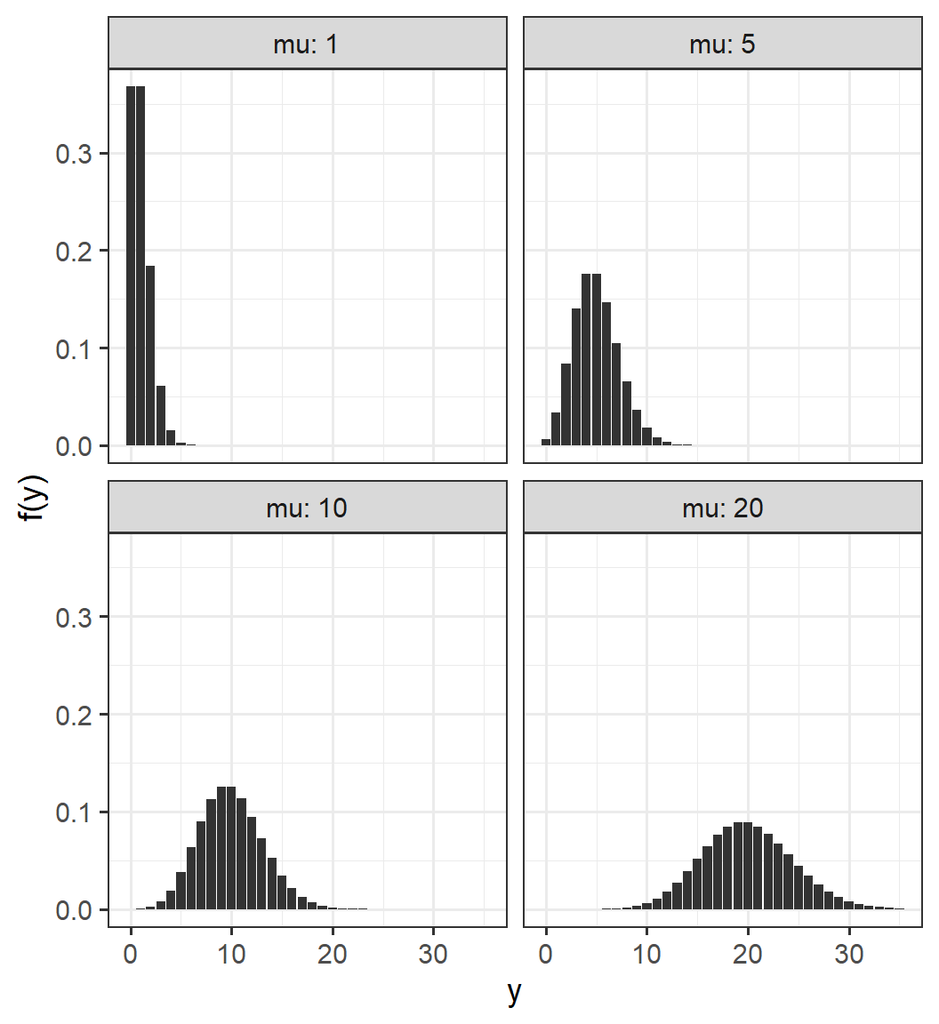

$$f(y)= \frac{\mu^y \cdot e^{-\mu}}{y!}$$

Параметр:

- $\mu$ – задает среднее и дисперсию.

Свойства:

- $E(y) = \mu$ — мат. ожидание;
- $var(y) = \mu$ — дисперсия;
- $0 \le y \le +\infty$, $y \in \mathbb{N}$ — значения.

## Отрицательное биномиальное распределение

[figure not shown]

$f(y) = \frac{\Gamma(y + k)}{\Gamma(k) \cdot \Gamma(y+1)} \cdot (\frac{k}{\mu + k})^k \cdot (1 - \frac{k}{\mu + k})^y$

Параметры:

- $\mu$ – среднее;
- $k$ – определяет степень избыточности дисперсии.

Свойства:

- $E(y) = \mu$ – мат. ожидание;
- $var(y) = \mu + \frac {\mu^2}{k}$ – дисперсия;
- $0 \le y \le +\infty$, $y \in \mathbb{N}$ – значения.

## Обобщенные линейные модели (Generalized Linear Models)

Обобщенные линейные модели (Nelder, Weddlerburn, 1972)

- Позволяют моделировать не только величины, подчиняющиеся нормальному распределению, но и другим распределениям из семейства экспоненциальных.
- Подбор коэффициентов делается методом максимального правдоподобия.

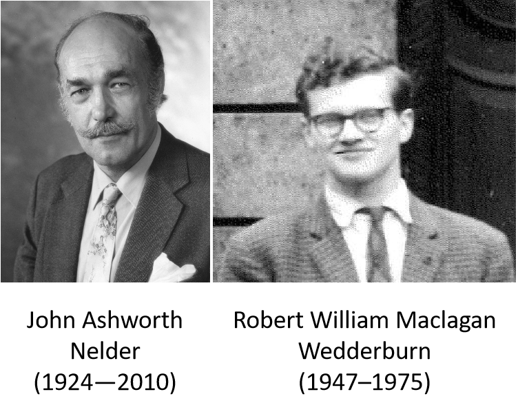

## Отличия обобщенной линейной модели от общей

На примере нормального распределения $\color{purple}{f(y_i|\theta) = N(\mu_i, \sigma)}$

### Общая линейная модель состоит из двух компонентов

$\color{purple}{y_i \sim f(y_i|\theta)}$

$\color{teal}{E(y_i) = \mu_i = \beta_0 + \beta_1 x_{1i} + ... + \beta_{p-1}x_{p-1\,i}}$

### Обобщенная линейная модель состоит из трех компонентов

$\color{purple}{y_i \sim f(y_i|\theta)}$

$\color{green}{E(y_i) = \mu_i = g^{-1}(\beta_0 + \beta_1 x_{1i} + ... + \beta_{p-1}x_{p-1\,i})}$

$\color{red}{g(\mu_i) = \eta_i}$

$\color{blue}{\eta_i = \beta_0 + \beta_1 x_{1i} + ... + \beta_{p-1}x_{p-1\,i}}$

- Случайная часть — $\color{purple}{y_i \sim f(y_i|\theta)}$ — распределение из семейства экспоненциальных с параметрами $\theta$.
- Фиксированная часть: $\color{red}{g()}$ — **функция связи**, трансформирует **мат. ожидание отклика** в **линейный предиктор** $\color{blue}{\eta_i}$ (обратная функция связи обозначается $\color{green}{g^{-1}()}$).

## Функция связи

$\color{purple}{y_i \sim f(y_i|\theta)}$

$\color{green}{E(y_i) = \mu_i = g^{-1}(\beta_0 + \beta_1 x_{1i} + ... + \beta_{p-1}x_{p-1\,i})}$

$\color{red}{g(\mu_i) = \eta_i}$

$\color{blue}{\eta_i = \beta_0 + \beta_1 x_{1i} + ... + \beta_{p-1}x_{p-1\,i}}$

**Функция связи** $\color{red}{g(\mu)}$ разная в зависимости **от распределения отклика** $\color{purple}{f(y_i|\theta)}$

## Функция связи: идентичность

$\color{purple}{y_i \sim f(y_i|\theta)}$

$\color{green}{E(y_i) = \mu_i = g^{-1}(\beta_0 + \beta_1 x_{1i} + ... + \beta_{p-1}x_{p-1\,i})}$

$\color{red}{g(\mu_i) = \eta_i}$

$\color{blue}{\eta_i = \beta_0 + \beta_1 x_{1i} + ... + \beta_{p-1}x_{p-1\,i}}$

**Функция связи** $\color{red}{g(\mu)}$ разная в зависимости **от распределения отклика** $\color{purple}{f(y_i|\theta)}$

$\color{purple}{y_i \sim N(\mu_i, \sigma)}$

$\color{green}{E(y_i) = \mu_i \phantom{\frac{e^{\beta_0}}{1 + e^{\beta_0}}}}$

$\color{red}{\mu_i = \eta_i}$ **— идентичность**

$\color{blue}{\eta_i = \beta_0 + \beta_1 x_{1i} + ... + \beta_{p-1}x_{p-1\,i}}$

## Функция связи: логарифм

$\color{purple}{y_i \sim f(y_i|\theta)}$

$\color{green}{E(y_i) = \mu_i = g^{-1}(\beta_0 + \beta_1 x_{1i} + ... + \beta_{p-1}x_{p-1\,i})}$

$\color{red}{g(\mu_i) = \eta_i}$

$\color{blue}{\eta_i = \beta_0 + \beta_1 x_{1i} + ... + \beta_{p-1}x_{p-1\,i}}$

**Функция связи** $\color{red}{g(\mu)}$ разная в зависимости **от распределения отклика** $\color{purple}{f(y_i|\theta)}$

Например, $\color{purple}{y_i \sim Poisson(\mu_i)}$

$\color{green}{E(y_i) = e^{\beta_0 + \beta_1 x_{1i} + ... + \beta_{p-1}x_{p-1\,i}} \phantom{\frac{e^{\beta_0}}{1 + e^{\beta_0}}}}$

$\color{red} {ln(\mu_i) = \eta_i}$ **— логарифм**

$\color{blue}{\eta_i = \beta_0 + \beta_1 x_{1i} + ... + \beta_{p-1}x_{p-1\,i}}$

## Функция связи: логит

$\color{purple}{y_i \sim f(y_i|\theta)}$

$\color{green}{E(y_i) = \mu_i = g^{-1}(\beta_0 + \beta_1 x_{1i} + ... + \beta_{p-1}x_{p-1\,i})}$

$\color{red}{g(\mu_i) = \eta_i}$

$\color{blue}{\eta_i = \beta_0 + \beta_1 x_{1i} + ... + \beta_{p-1}x_{p-1\,i}}$

**Функция связи** $\color{red}{g(\mu)}$ разная в зависимости **от распределения отклика** $\color{purple}{f(y_i|\theta)}$

Например, $\color{purple}{y_i \sim Binomial(n = 1, \pi_i)}$

$\color{green}{E(y_i) = \cfrac{e^{\beta_0 + \beta_1 x_{1i} + ... + \beta_{p-1}x_{p-1\,i}}}{1 + e^{\beta_0 + \beta_1 x_{1i} + ... + \beta_{p-1}x_{p-1\,i}}}}$

$\color{red} {ln\big(\cfrac{\mu_i}{1 - \mu_i}\big) = \eta_i}$ **— логит**

$\color{blue}{\eta_i = \beta_0 + \beta_1 x_{1i} + ... + \beta_{p-1}x_{p-1\,i}}$

## Параметры обобщенных линейных моделей подбирают методом максимального правдоподобия

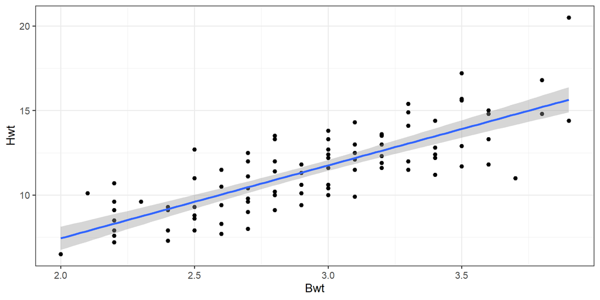

## Параметры обобщенных линейных моделей подбирают методом максимального правдоподобия

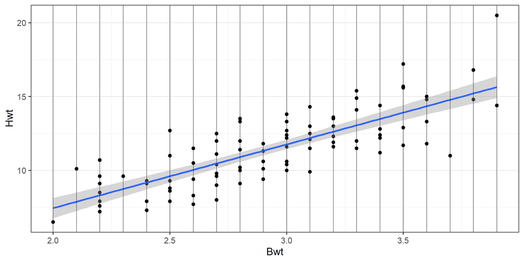

Для каждого значения предиктора (отложен по оси OX) есть некоторая выборка значений зависимой переменной.

## Параметры обобщенных линейных моделей подбирают методом максимального правдоподобия

Правдоподобие (likelihood) — измеряет соответствие реально наблюдаемых данных тем, что можно получить из модели при определенных значениях параметров.

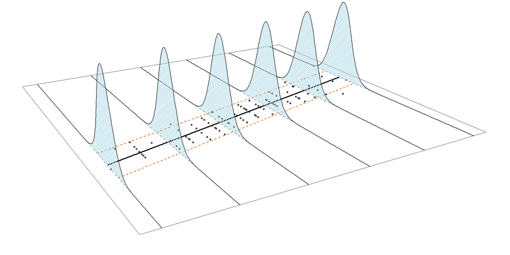

Это произведение вероятностей данных:

$$L(\theta| y_i) = \Pi^n _{i = 1}\color{purple}{f(y_i| \theta)}$$

Параметры модели должны максимизировать значение логарифма правдоподобия (loglikelihood):

$$lnL(\theta| y_i) \longrightarrow \text{max}$$

Для тех, кому интересно разобраться вот [хорошая визуализация работы ML и тестов, основанных на LR](https://rpsychologist.com/likelihood/)

Magnusson, K. (2020). Understanding Maximum Likelihood: An interactive visualization (Version 0.1.2) [Web App]. R Psychologist. https://rpsychologist.com/likelihood/

## ML-оценки для дисперсий – смещенные

Например, ML оценка обычной выборочной дисперсии будет смещенной:

Хотелось бы:

$\hat\sigma^2 = \cfrac{\sum(y_i - \hat y_i)^2}{n - p - 1}$,

На самом деле при ML:

$\hat\sigma^2 = \cfrac{\sum(y_i - \hat y_i)^2}{n}$,

т.к. в знаменателе не $n - p - 1$, а $n$.

Аналогичные проблемы возникают при ML оценках для случайных эффектов в линейных моделях.

Это происходит потому, что в смешанной линейной модели

$\mathbf{Y} = \mathbf{X} \pmb{\beta} + \mathbf{Z} \mathbf{b} + \pmb{\varepsilon}$

$\mathbf{Y} \sim N(\mathbf{X} \pmb{\beta}, \mathbf{V})$, где $\mathbf{V} = \mathbf{ZDZ'} + \pmb{\Sigma}$

т.е. одновременно приходится оценивать $\pmb{\beta}$ и $\mathbf{V}$.

## Пример – энергетическая ценность икры

## Пример – энергетическая ценность икры

Один из показателей, связанных с жизнеспособностью икры – доля сухого вещества. Она пропорциональна количеству запасенной энергии.

Отличается ли энергетическая ценность икры большой озерной форели в сентябре и ноябре?

[figure not shown]

Данные: Lantry et al., 2008  
Источник: пакет Stat2Data

## Открываем данные

```r
FishEggs <- read.table(file = "data/FishEggs.csv", sep = ";")
```

Все ли правильно открылось?

```r
str(FishEggs)
```

```
'data.frame':   35 obs. of  4 variables:
 $ Age  : int  7 8 8 9 9 9 9 10 10 11 ...
 $ PctDM: num  37.4 38 37.5 39 37.9 ...
 $ Month: chr  "Nov" "Nov" "Nov" "Nov" ...
 $ Sept : int  0 0 0 0 0 0 0 0 0 0 ...
```

Нет ли пропущенных значений?

```r
colSums(is.na(FishEggs))
```

```
  Age PctDM Month  Sept
    0     0     0     0
```

## Меняем порядок уровней факторов

Уровни факторов в исходных данных:

```r
FishEggs$Month <- factor(FishEggs$Month)

levels(FishEggs$Month)
```

```
[1] "Nov" "Sep"
```

Делаем базовым уровнем сентябрь.

```r
FishEggs$Month <- relevel(FishEggs$Month, ref = 'Sep')
```

Теперь уровни в хронологическом порядке:

```r
levels(FishEggs$Month)
```

```
[1] "Sep" "Nov"
```

## Объемы выборок

```r
table(FishEggs$Month)
```

```
Sep Nov
 14  21
```

## Ищем выбросы

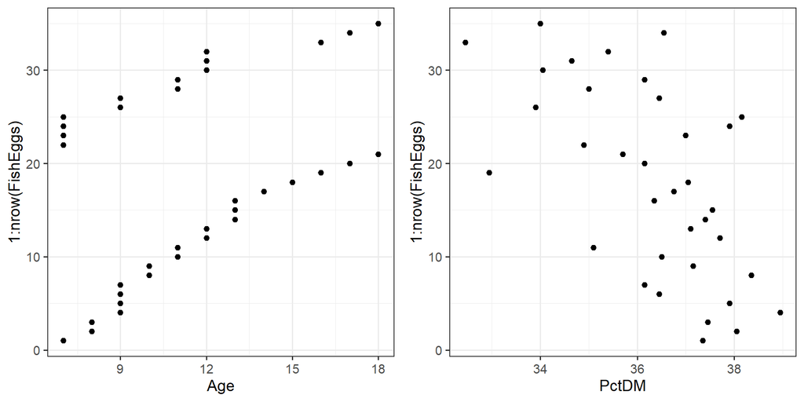

```r
library(cowplot)

gg_dot <- ggplot(FishEggs, aes(y = 1:nrow(FishEggs))) + geom_point()
plot_grid(gg_dot + aes(x = Age),
          gg_dot + aes(x = PctDM), nrow = 1)
```

## Модель для описания питательной ценности икры

### GLM с нормальным распределением отклика

$y_i \sim N(\mu_i, \sigma)$  
$E(y_i) = \mu_i$  
$\mu_i = \eta_i$ — функция связи “идентичность” (identity)  
$\eta_i = \beta_0 + \beta_1 x_{1i} + ... + \beta_{p-1}x_{p-1\,i}$

## Модель зависимости в нашем примере

Как зависит питательная ценность икры от месяца вылова рыбы (сентябрь или ноябрь) с учетом ковариаты (возраста рыбы) и их взаимодействия.

$PctDM_i \sim N(\mu_i, \sigma)$  
$E(PctDM_i) = \mu_i$  
$\mu_i = \eta_i$  
$\eta_i = \beta_0 + \beta_1 Age_{i} + \beta_2 Month_{Nov\,i} + \beta_{3} Age_{i} Month_{Nov\,i}$

- $PctDM_i$ — содержание сухого вещества в икре;
- $Age_{i}$ — возраст рыбы;
- $Month_{Nov\,i}$ – переменная-индикатор для уровня $Month_{Nov\,i} = 1$.

## Подбираем модель

```r
mod <- glm(PctDM ~ Age * Month, data = FishEggs)
mod
```

```
Call:  glm(formula = PctDM ~ Age * Month, data = FishEggs)

Coefficients:
 (Intercept)           Age      MonthNov  Age:MonthNov
    38.12111      -0.23965       1.27623       0.02144

Degrees of Freedom: 34 Total (i.e. Null);  31 Residual
Null Deviance:      83.96
Residual Deviance: 47.83    AIC: 120.3
```

```r
# Чтобы записать модель, нужна еще сигма.
sigma(mod)
```

```
[1] 1.242124
```

$PctDM_i \sim N(\mu_i, 1.24)$  
$E(PctDM_i) = \mu_i$  
$\mu_i = \eta_i$  
$\eta_i = 38.12 - 0.24 Age_{i} + 1.28 Month_{Nov\,i} + 0.02 Age_{i} Month_{Nov\,i}$

## Диагностика модели

## Разновидности остатков в GLM

### Остатки в масштабе отклика (response residuals)

$$e_i = y_i - E(y_i)$$

- Это разница между наблюдаемым и предсказанным значениями.
- Аналог (и синоним) “сырых” остатков в простой линейной регрессии.

### Пирсоновские остатки (Pearson’s residuals)

$$r_{p\,i} = \frac{y_i - E(y_i)}{\sqrt{var(y_i)}}$$

- Это обычные остатки, деленные на стандартную ошибку предсказанного значения.
- Аналог стандартизованных остатков в простой линейной регрессии.

```r
resid(mod, type = 'response')[1:4]
```

```
         1          2          3          4
-0.5198421  0.3983712 -0.2016288  1.5165844
```

```r
resid(mod, type = 'pearson')[1:4]
```

```
         1          2          3          4
-0.5198421  0.3983712 -0.2016288  1.5165844
```

Для GLM с нормальным распределением отклика оба типа остатков одинаковы.

## Условия применимости GLM с нормальным распределением отклика

- Случайность и независимость наблюдений внутри групп.
- Нормальное распределение остатков.
- Гомогенность дисперсий остатков.
- Отсутствие коллинеарности предикторов.

## Проверка на коллинеарность

Мы и так знаем, что в параметризации индикаторных переменных взаимодействие будет коллинеарно со своими составляющими (и это нормально, см. прошлую лекцию).

Важно проверить, будут ли коллинеарны другие предикторы.

```r
library(car)
vif(update(mod, . ~ . - Age:Month))
```

```
     Age    Month
1.006666 1.006666
```

Коллинеарности нет.

## Данные для анализа остатков

```r
mod_diag <- fortify(mod) # функция из пакета ggplot2
head(mod_diag)
```

```
  PctDM Age Month       .hat   .sigma      .cooksd  .fitted     .resid
1 37.35   7   Nov 0.15819348 1.258412 0.0097750037 37.86984 -0.5198421
2 38.05   8   Nov 0.11549852 1.260286 0.0037963407 37.65163  0.3983712
3 37.45   8   Nov 0.11549852 1.262050 0.0009725112 37.65163 -0.2016288
4 38.95   9   Nov 0.08316881 1.229097 0.0368743995 37.43342  1.5165844
5 37.90   9   Nov 0.08316881 1.259518 0.0034902153 37.43342  0.4665844
6 36.45   9   Nov 0.08316881 1.248655 0.0155047929 37.43342 -0.9834156
   .stdresid
1 -0.4561423
2  0.3410151
3 -0.1725990
4  1.2751372
5  0.3923020
6 -0.8268513
```

## График расстояния Кука

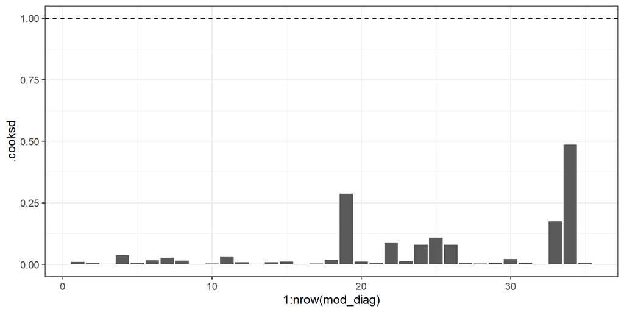

```r
ggplot(mod_diag, aes(x = 1:nrow(mod_diag), y = .cooksd)) +
  geom_bar(stat = 'identity') +
  geom_hline(yintercept = 1, linetype = 2)
```

Влиятельных наблюдений нет.

## График остатков от предсказанных значений

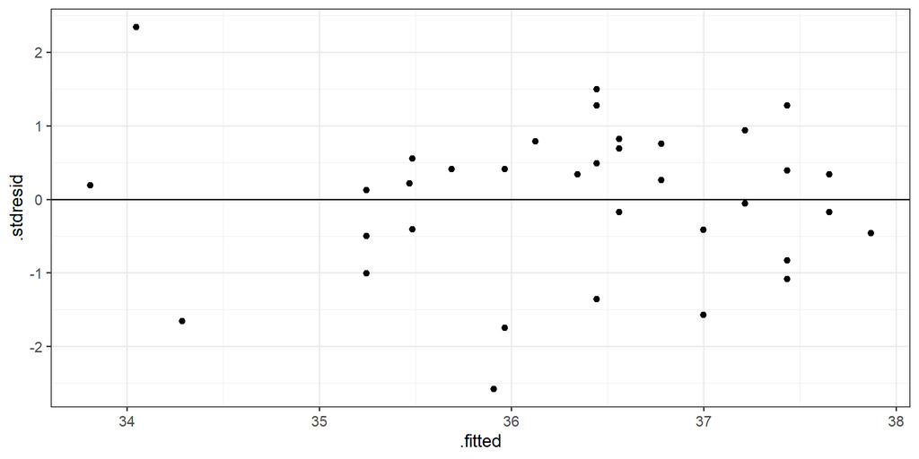

```r
gg_resid <- ggplot(data = mod_diag, aes(x = .fitted, y = .stdresid)) +
  geom_point() + geom_hline(yintercept = 0)
gg_resid
```

Влиятельных наблюдений нет.  
Мало данных в области с небольшими предсказанными значениями.

## График зависимости остатков от предикторов в модели

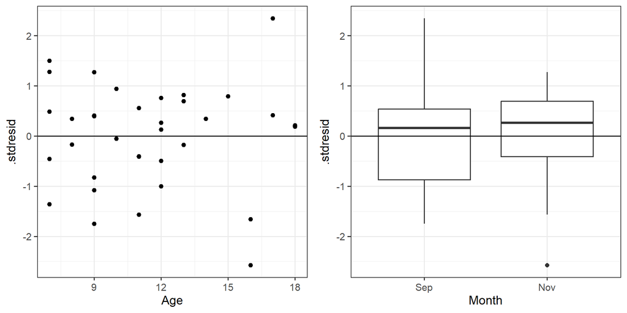

```r
ggplot(data = mod_diag, aes(x = Age, y = .stdresid)) +
  geom_point() + geom_hline(yintercept = 0)
ggplot(data = mod_diag, aes(x = Month, y = .stdresid)) +
  geom_boxplot() + geom_hline(yintercept = 0)
```

Нет выраженной гетероскедастичности.

## Тестирование значимости коэффициентов

## Тест Вальда для коэффициентов GLM

$H_0: \beta_k = 0$  
$H_A: \beta_k \ne 0$

$$\frac{b_k - \beta_k} {SE_{b_k}} = \frac{b_k} {SE_{b_k}} \sim N(0, 1)$$

- $b_k$ — оценка коэффициента GLM.

Хорошо работает только на больших выборках (Agresty, 2007).

Если приходится оценивать $\sigma$, то $\frac{b_k} {SE_{b_k}} \sim t_{(df = n - p)}$

- $n$ — объем выборки.
- $p$ — число параметров модели.

## В `summary()` записаны результаты теста Вальда

```
Call:
glm(formula = PctDM ~ Age * Month, data = FishEggs)

Coefficients:
             Estimate Std. Error t value Pr(>|t|)
(Intercept)  38.12111    1.06436  35.816   <2e-16 ***
Age          -0.23965    0.09134  -2.624   0.0134 *
MonthNov      1.27623    1.51190   0.844   0.4051
Age:MonthNov  0.02144    0.12782   0.168   0.8679
---
Signif. codes:  0 '***' 0.001 '**' 0.01 '*' 0.05 '.' 0.1 ' ' 1

(Dispersion parameter for gaussian family taken to be 1.542872)

    Null deviance: 83.962  on 34  degrees of freedom
Residual deviance: 47.829  on 31  degrees of freedom
AIC: 120.26

Number of Fisher Scoring iterations: 2
```

## Анализ девиансы

## Шкала для сравнения моделей

**Насыщенная модель** — каждое уникальное наблюдение (сочетание значений предикторов) описывается одним из $n$ параметров.

$lnL_{saturated} = 0$  
$df_{saturated} = n - p_{saturated} = n - n = 0$

**Предложенная модель** — модель, подобранная в данном анализе $\hat y_i = \beta_0 + \beta_1x_{1i} + \ldots + \beta_{p - 1} x_{p - 1\,i}$.

$lnL_{model} \ne 0$  
$df_{model} = n - p_{model}$

**Нулевая модель** – все наблюдения описываются одним параметром (средним) $\hat y_i = \beta_0$.

$lnL_{null} \ne 0$  
$df_{null} = n - p_{null} = n - 1$

## Девианса

Это мера различия правдоподобий двух моделей (оценка разницы логарифмов правдоподобий).

**Остаточная девианса**

$d_{residual} = 2(lnL_{saturated} - lnL_{model}) = -2 lnL_{model}$

**Нулевая девианса**

$d_{null} = 2(lnL_{saturated} - lnL_{null}) = -2 lnL_{null}$

Сравнение нулевой и остаточной девианс позволяет судить о статистической значимости модели в целом (при помощи теста отношения правдоподобий).

$d_{null} - d_{residual} = - 2(lnL_{null} - lnL_{model}) = 2(lnL_{model} - lnL_{null})$

## Тест отношения правдоподобий (Likelihood Ratio Test)

Тест отношения правдоподобий (Wilks, 1938) используется для сравнения правдоподобий

$$LRT = 2ln\Big(\frac{L_{M_1}}{L_{M_2}}\Big) = 2(lnL_{M_1} - lnL_{M_2})$$

- $M_1$ и $M_2$ — вложенные модели ( $M_1$ — более полная, $M_2$ — уменьшенная),
- $L_{M_1}$, $L_{M_2}$ — правдоподобия,
- $lnL_{M_1}$, $lnL_{M_2}$ — логарифмы правдоподобий.

Сравниваются **вложенные модели, подобранные методом максимального правдоподобия**.

Разница логарифмов правдоподобий $LRT$ имеет распределение, которое можно аппроксимировать распределением $\chi^2$ с числом степеней свободы $df = df_{M_2} - df_{M_1}$.

## LRT используется для сравнения моделей

Для тестирования значимости модели целиком:

$$LRT = 2ln\Big(\frac{L_{model}}{L_{null}}\Big) = 2(lnL_{model} - lnL_{null}) = d_{null} - d_{residual}$$

$df = df_{null} - df_{model} = (n - 1) - (n - p_{model}) = p_{model} - 1$

Для тестирования значимости предикторов:

$$LRT = 2ln\Big(\frac{L_{model}}{L_{reduced}}\Big) = 2(lnL_{model} - lnL_{reduced})$$

$df = df_{reduced} - df_{model} = (n - p_{reduced}) - (n - p_{model}) = p_{model} - p_{reduced}$

## Тестируем значимость модели целиком при помощи LRT

```r
?anova.glm
```

```r
null_model <- glm(PctDM ~ 1, data = FishEggs)
anova(null_model, mod, test = 'Chi')
```

```
Analysis of Deviance Table

Model 1: PctDM ~ 1
Model 2: PctDM ~ Age * Month
  Resid. Df Resid. Dev Df Deviance  Pr(>Chi)
1        34     83.962
2        31     47.829  3   36.133 3.302e-05 ***
---
Signif. codes:  0 '***' 0.001 '**' 0.01 '*' 0.05 '.' 0.1 ' ' 1
```

## Тестируем значимость предикторов при помощи LRT

Используем II тип тестов (“II тип сумм квадратов”):

**1. Тестируем значимость взаимодействия**

```r
drop1(mod, test = 'Chi')
```

```
Single term deletions

Model:
PctDM ~ Age * Month
          Df Deviance    AIC scaled dev. Pr(>Chi)
<none>         47.829 120.26
Age:Month  1   47.872 118.29    0.031735   0.8586
```

## 2. Тестируем значимость предикторов, когда взаимодействие удалено

```r
mod_no_int <- update(mod, . ~ . -Age:Month)
drop1(mod_no_int, test = 'Chi')
```

```
Single term deletions

Model:
PctDM ~ Age + Month
       Df Deviance    AIC scaled dev.  Pr(>Chi)
<none>      47.872 118.29
Age     1   67.638 128.38      12.097 0.0005051 ***
Month   1   67.133 128.12      11.835 0.0005813 ***
---
Signif. codes:  0 '***' 0.001 '**' 0.01 '*' 0.05 '.' 0.1 ' ' 1
```

## Запись результатов LRT-тестов значимости предикторов

Содержание сухого вещества в икре зависит от возраста рыбы и месяца (p < 0.01, тест отношения правдоподобий, табл. 1). Характер зависимости энергетической ценности икры от возраста одинаков в сентябре и ноябре.

Анализ девиансы для модели зависимости энергетической ценности икры от возраста рыбы, месяца и их взаимодействия. Тесты II типа.

| Предиктор | df | D | p |
| --- | --- | --- | --- |
| - |  | 47.829 |  |
| Возраст:Месяц | 1 | 47.872 | 0.86 |
| Возраст | 1 | 67.638 | <0.01 |
| Месяц | 1 | 67.133 | <0.01 |

## Описание качества подгонки GLM

## Доля объясненной девиансы

**Остаточная девианса**

$d_{residual} = 2(lnL_{saturated} - lnL_{model}) = -2 lnL_{model}$

**Нулевая девианса**

$d_{null} = 2(lnL_{saturated} - lnL_{null}) = -2 lnL_{null}$

**Доля объясненной девиансы**

$\cfrac{d_{null} - d_{residual}}{d_{null}}$

Доля объясненной девиансы — аналог $R^2$, одна из характеристик качества подгонки модели.

Долю объясненной девиансы легко вычислить

```r
(mod$null.deviance - mod$deviance) / mod$null.deviance
```

```
[1] 0.4303481
```

Модель объясняет 43% девиансы.

## График предсказаний модели

## Задание 1

Постройте график предсказаний модели.

## Данные для графика предсказаний

```r
library(dplyr)
New_Data <- FishEggs %>%
  group_by(Month) %>%
  do(data.frame(Age = seq(min(.$Age), max(.$Age), length.out = 100)))
head(New_Data)
```

```
# A tibble: 6 × 2
# Groups:   Month [1]
  Month   Age
  <fct> <dbl>
1 Sep    7
2 Sep    7.11
3 Sep    7.22
4 Sep    7.33
5 Sep    7.44
6 Sep    7.56
```

## Предсказания при помощи `predict()`

```r
Predictions <- predict(mod, newdata = New_Data, se.fit = TRUE)
New_Data$fit <- Predictions$fit  # Предсказанные значения
New_Data$se <- Predictions$se.fit # Стандартные ошибки
t_crit <- qt(0.975, df = nrow(FishEggs) - length(coef(mod)) - 1) # t для дов. инт.
New_Data$lwr <- New_Data$fit - t_crit * New_Data$se
New_Data$upr <- New_Data$fit + t_crit * New_Data$se

head(New_Data)
```

```
# A tibble: 6 × 6
# Groups:   Month [1]
  Month   Age   fit    se   lwr   upr
  <fct> <dbl> <dbl> <dbl> <dbl> <dbl>
1 Sep    7     36.4 0.499  35.4  37.5
2 Sep    7.11  36.4 0.491  35.4  37.4
3 Sep    7.22  36.4 0.484  35.4  37.4
4 Sep    7.33  36.4 0.476  35.4  37.3
5 Sep    7.44  36.3 0.469  35.4  37.3
6 Sep    7.56  36.3 0.462  35.4  37.3
```

## Данные для графика вручную

```r
X <- model.matrix(~ Age * Month, data = New_Data) # Модельная матрица
betas <- coef(mod) # Коэффициенты
New_Data$fit <- X %*% betas  # Предсказанные значения
New_Data$se <- sqrt(diag(X %*% vcov(mod) %*% t(X))) # Стандартные ошибки
t_crit <- qt(0.975, df = nrow(FishEggs) - length(coef(mod)) - 1) # t для дов. инт.
New_Data$lwr <- New_Data$fit - t_crit * New_Data$se
New_Data$upr <- New_Data$fit + t_crit * New_Data$se

head(New_Data)
```

```
# A tibble: 6 × 6
# Groups:   Month [1]
  Month   Age fit[,1]    se lwr[,1] upr[,1]
  <fct> <dbl>   <dbl> <dbl>   <dbl>   <dbl>
1 Sep    7       36.4 0.499    35.4    37.5
2 Sep    7.11    36.4 0.491    35.4    37.4
3 Sep    7.22    36.4 0.484    35.4    37.4
4 Sep    7.33    36.4 0.476    35.4    37.3
5 Sep    7.44    36.3 0.469    35.4    37.3
6 Sep    7.56    36.3 0.462    35.4    37.3
```

## График предсказаний модели

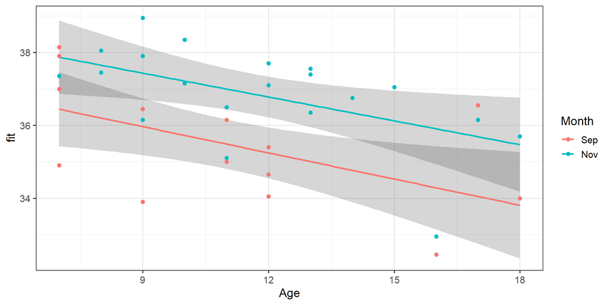

```r
Plot_egg <- ggplot(New_Data, aes(x = Age, y = fit)) +
  geom_ribbon(alpha = 0.2, aes(ymin = lwr, ymax = upr, group = Month)) +
  geom_line(aes(colour = Month), size = 1) +
  geom_point(data = FishEggs, aes(x = Age, y = PctDM, colour = Month))
Plot_egg
```

## Отбор моделей для GLM (model selection)

## Подбор “оптимальной” модели

В подобранной модели можно протестировать значимость влияния предикторов и их взаимодействия и на этом остановиться.

Или можно упростить модель, аналогично тому, как мы это делали со множественной линейной регрессией, но использовав LRT вместо F-теста.

## Пытаемся сократить модель

```r
mod_no_int <- update(mod, . ~ . -Age:Month)
drop1(mod_no_int, test = 'Chi')
```

```
Single term deletions

Model:
PctDM ~ Age + Month
       Df Deviance    AIC scaled dev.  Pr(>Chi)
<none>      47.872 118.29
Age     1   67.638 128.38      12.097 0.0005051 ***
Month   1   67.133 128.12      11.835 0.0005813 ***
---
Signif. codes:  0 '***' 0.001 '**' 0.01 '*' 0.05 '.' 0.1 ' ' 1
```

Если мы решили “сократить” модель, то теперь придется описать модель `mod_no_int`.

## Уравнение сокращенной модели

```r
mod_no_int
```

```
Call:  glm(formula = PctDM ~ Age + Month, data = FishEggs)

Coefficients:
(Intercept)          Age     MonthNov
    37.9999      -0.2287       1.5193

Degrees of Freedom: 34 Total (i.e. Null);  32 Residual
Null Deviance:      83.96
Residual Deviance: 47.87    AIC: 118.3
```

```r
#Чтобы записать модель,нужна сигма

sigma(mod_no_int)
```

```
[1] 1.223116
```

$PctDM_i \sim N(\mu_i, 1.22)$  
$E(PctDM_i) = \mu_i$  
$\mu_i = \eta_i$  
$\eta_i = 38.0 - 0.23 Age_{i} + 1.52 Month_{Nov\,i}$

- $PctDM_i$ — содержание сухого вещества в икре;
- $Age_{i}$ — возраст рыбы.

## Информационные критерии — еще один способ сравнения или упрощения моделей

## Информационный критерий Акаике (Akaike Information Criterion, AIC)

$$AIC = -2 logLik + 2p$$

- $logLik$ — логарифм правдоподобия для модели;
- $2p$ — штраф за введение в модель $p$ параметров, т.е. за “сложность” модели

AIC — это мера потери информации, которая происходит, если реальность описывать этой моделью (Akaike 1974)

AIC — относительная мера качества модели. Т.е. не бывает какого-то “хорошего” AIC. Значения AIC можно интерпретировать только в сравнении с AIC для других моделей: чем меньше AIC — тем лучше модель.

**Важно!** Информационные критерии можно использовать для сравнения **даже для невложенных моделей**. Но модели должны быть **подобраны с помощью ML** и **на одинаковых данных**!

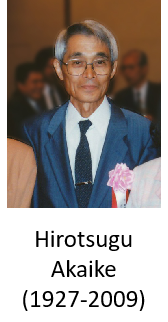

## Некоторые другие информационные критерии

| Критерий | Название | Формула |
| --- | --- | --- |
| AIC | Информационный критерий Акаике | $AIC = -2 logLik + 2p$ |
| BIC | Байесовский информационный критерий | $BIC = -2 logLik + p \cdot ln(n)$ |
| AICc | Информационный критерий Акаике с коррекцией для малых выборок (малых относительно числа параметров: $n/p < 40$, Burnham, Anderson, 2004) | $AIC_c = -2 logLik + 2p + \frac{2p(p + 1)}{n - p - 1}$ |

- $logLik$ — логарифм правдоподобия для модели;
- $p$ — число параметров;
- $n$ — число наблюдений.

## Как рассчитать AIC в GLM?

$$AIC = -2 logLik + 2p$$
**В GLM с нормальным распределением отклика число параметров — это число коэффициентов + 1**, т.к. появился дополнительный параметр $\sigma$

$PctDM_i \sim N(\mu_i, 1.22)$  
$E(PctDM_i) = \mu_i$  
$\mu_i = \eta_i$  
$\eta_i = 38.0 - 0.23 Age_{i} + 1.52 Month_{Nov\,i}$

```r
(p <- length(coef(mod_no_int)) + 1) # число параметров
```

```
[1] 4
```

```r
logLik(mod_no_int)         # Логарифм правдоподобия
```

```
'log Lik.' -55.1437 (df=4)
```

```r
as.numeric(-2 * logLik(mod_no_int) + 2 * p)
```

```
[1] 118.2874
```

```r
AIC(mod_no_int) # Есть готовая функция
```

```
[1] 118.2874
```

## AIC удобно использовать для сравнения моделей, даже невложенных

Пусть у нас есть несколько моделей:

```r
mod <-        glm(formula = PctDM ~ Age * Month, data = FishEggs)
mod_no_int <- glm(formula = PctDM ~ Age + Month, data = FishEggs)
mod_age <-    glm(formula = PctDM ~ Age,         data = FishEggs)
mod_month <-  glm(formula = PctDM ~ Month,       data = FishEggs)
```

```r
AIC(mod, mod_no_int, mod_age, mod_month)
```

```
           df      AIC
mod         5 120.2557
mod_no_int  4 118.2874
mod_age     3 128.1223
mod_month   3 128.3842
```

Судя по AIC, лучшая модель `mod_no_int`.

Если значения AIC различаются всего на 1-2 единицу — такими различиями можно пренебречь и выбрать более простую модель (`mod_no_int`).

## Проверка валидности финальной модели

```r
library(DHARMa)
simulateResiduals(mod_no_int, plot = T)
```

```
Object of Class DHARMa with simulated residuals based on 250 simulations with refit = FALSE . See ?DHARMa::simulateResiduals for help.

Scaled residual values: 0.34 0.596 0.44 0.872 0.692 0.22 0.12 0.804 0.464 0.32 0.06 0.772 0.58 0.756 0.82 0.388 0.608 0.828 0 0.64 ...
```

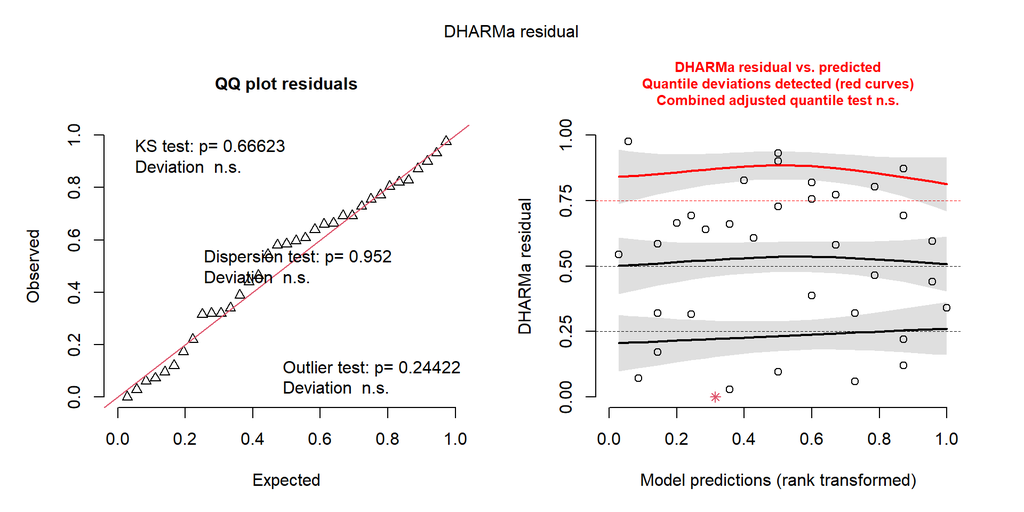

## `summary` финальной модели

```r
summary(mod_no_int)
```

```
Call:
glm(formula = PctDM ~ Age + Month, data = FishEggs)

Coefficients:
            Estimate Std. Error t value Pr(>|t|)
(Intercept) 37.99993    0.76950  49.383  < 2e-16 ***
Age         -0.22870    0.06292  -3.635 0.000965 ***
MonthNov     1.51929    0.42342   3.588 0.001096 **
---
Signif. codes:  0 '***' 0.001 '**' 0.01 '*' 0.05 '.' 0.1 ' ' 1

(Dispersion parameter for gaussian family taken to be 1.496013)

    Null deviance: 83.962  on 34  degrees of freedom
Residual deviance: 47.872  on 32  degrees of freedom
AIC: 118.29

Number of Fisher Scoring iterations: 2
```

## Take-home messages

- Обобщенные линейные модели (Generalized Linear Models, GLM) позволяют моделировать зависимости для откликов с распределением из семейства экспоненциальных
- Для тестирования предикторов в GLM используются:
  - Тесты Вальда для коэффициентов (плохо на малых выборках).
  - Тесты отношения правдоподобий вложенных моделей (более точно).
- Доля объясненной девиансы оценивает качество подгонки GLM
- Сравнивая модели можно отбраковать переменные, включение которых в модель не улучшает ее
- **Метод сравнения моделей нужно выбрать заранее, еще до анализа**

## Что почитать

- **Zuur, A.F. and Ieno, E.N., 2016. A protocol for conducting and presenting results of regression-type analyses. Methods in Ecology and Evolution, 7(6), pp.636-645.**
- Кабаков Р.И. R в действии. Анализ и визуализация данных на языке R. М.: ДМК Пресс, 2014
- **Zuur, A., Ieno, E.N. and Smith, G.M., 2007. Analyzing ecological data. Springer Science & Business Media.**
- Quinn G.P., Keough M.J. 2002. Experimental design and data analysis for biologists
- Logan M. 2010. Biostatistical Design and Analysis Using R. A Practical Guide